# Test Cointegration

Kevin Lu

December 10, 2017

# 1. Load Packages

```r
source("./Mean Reversion/TMR.001 Load Packages.R")
```

# 2. Load Data

```r
pricing_data <- read_csv("./Mean Reversion/Raw Data/pricing data.csv")
```

# 3. Spread Data

Data was previous gathered in tidy format. For preliminary analysis, filter data to daily time resolution and data after April 1, 2017. Based on some exploratory analysis, the number of cointegrated coins rapidly increased after April 1, 2017. This time period coincides with an extremely rapid rise of bitcoin (starting from roughly $1100) and many other coins.

```r
pricing_data_a <- pricing_data %>%
  filter(period == 86400,
         date_time >= "2017-04-01") %>%
  select(date_unix, date_time, close, currency_pair) %>%
  spread(currency_pair, close)
print(pricing_data_a)
```

```
## # A tibble: 255 x 19
##     date_unix  date_time   BTC_DASH    BTC_DCR    BTC_ETH    BTC_FCT
##  *      <dbl>     <dttm>      <dbl>      <dbl>      <dbl>      <dbl>
##  1 1491091200 2017-04-02 0.05100000 0.01011847 0.04370309 0.00362110
##  2 1491177600 2017-04-03 0.05499499 0.00946908 0.03819766 0.00369028
##  3 1491264000 2017-04-04 0.06040060 0.00885499 0.03877701 0.00367109
##  4 1491350400 2017-04-05 0.06596799 0.00913248 0.03969998 0.00380000
##  5 1491436800 2017-04-06 0.05626999 0.00818990 0.03618000 0.00373181
##  6 1491523200 2017-04-07 0.05628618 0.00753000 0.03528362 0.00361651
##  7 1491609600 2017-04-08 0.05751002 0.00955076 0.03747400 0.00391400
##  8 1491696000 2017-04-09 0.05452689 0.01010800 0.03609801 0.00376150
##  9 1491782400 2017-04-10 0.05192000 0.00964000 0.03615636 0.00392035
## 10 1491868800 2017-04-11 0.05046000 0.00944139 0.03569304 0.00384259
## # ... with 245 more rows, and 13 more variables: BTC_LSK <dbl>,
## #   BTC_LTC <dbl>, BTC_REP <dbl>, BTC_XEM <dbl>, BTC_XMR <dbl>,
## #   BTC_ZEC <dbl>, USDT_BTC <dbl>, USDT_DASH <dbl>, USDT_ETH <dbl>,
## #   USDT_LTC <dbl>, USDT_REP <dbl>, USDT_XMR <dbl>, USDT_ZEC <dbl>
```

# 4. Cointegration Function

The Engle-Granger method is used to test for cointegration. This method is comprised of two steps: (1) Perform a linear regression of coin_y on coin_x. (2) Perform an Augmented Dickey-Fuller test on the residuals from the linear regression estimated in (1). The ADF test assumes a non-zero mean but no time-based trend. The function returns the Dickey-Fuller test statistic, the critical values at 1 percent, 5 percent, and 10 percent, and the half-life of mean reversion assuming that the mean reversion follows a Ornsteinâ€“Uhlenbeck process. Note that the p-value is calculated from a distribution where the linear regression coefficients are not estimated from the data. Since the regression coefficients are estimated from the data, the p-value is biased downward, so interpretation of the p-value relative to critical values should be done with caution.

Other methods considered were the Johansen test and the Phillips-Ouliaris cointegration test. Using different methods may lead to different conclusions when looking at test statistics relative to critical values.

```r
test_cointegration <- function(coin_y, coin_x) {
  lm_model <- lm(coin_y ~ coin_x)
  residuals <- lm_model[["residuals"]]
  adf_test <- ur.df(residuals, type = "drift", lags = 1)
  ou_process <- lm(residuals - lag(residuals, 1) ~ lag(residuals, 1))
  return(list(df_stat = adf_test@testreg[["coefficients"]][2, 3],
              crit_value_1pct = adf_test@cval[1, 1],
              crit_value_5pct = adf_test@cval[1, 2],
              crit_value_10pct = adf_test@cval[1, 3],
              half_life = -log(2) / coef(ou_process)[2]))
}
```

# 5. Create Coin Combinations

```r
coins_usdt <- c("USDT_BTC", "USDT_DASH", "USDT_ETH", "USDT_LTC", "USDT_REP", "USDT_XMR", "USDT_ZEC")
coins_btc <- c("BTC_DASH", "BTC_ETH", "BTC_LTC", "BTC_REP", "BTC_XEM", "BTC_XMR", "BTC_ZEC", "BTC_DCR", "BTC_FCT", "BTC_LSK")
coin_pairs <- rbind(expand.grid(coins_usdt, coins_usdt), expand.grid(coins_btc, coins_btc)) %>%
  as_tibble() %>%
  rename(coin_y = Var1, coin_x = Var2) %>%
  filter(coin_y != coin_x) %>%
  mutate_if(is.factor, as.character)
print(coin_pairs)
```

```
## # A tibble: 132 x 2
##       coin_y    coin_x
##        <chr>     <chr>
##  1 USDT_DASH  USDT_BTC
##  2  USDT_ETH  USDT_BTC
##  3  USDT_LTC  USDT_BTC
##  4  USDT_REP  USDT_BTC
##  5  USDT_XMR  USDT_BTC
##  6  USDT_ZEC  USDT_BTC
##  7  USDT_BTC USDT_DASH
##  8  USDT_ETH USDT_DASH
##  9  USDT_LTC USDT_DASH
## 10  USDT_REP USDT_DASH
## # ... with 122 more rows
```

# 6. Test Cointegration on All Coin Pairs

```r
df_stat <- c()
crit_value_1pct <- c()
crit_value_5pct <- c()
crit_value_10pct <- c()
half_life <- c()
for (n in 1:nrow(coin_pairs)) {
  coin_y <- coin_pairs[[n, "coin_y"]]
  coin_x <- coin_pairs[[n, "coin_x"]]
  cointegration_results<- test_cointegration(pricing_data_a[[coin_y]],
                                             pricing_data_a[[coin_x]])
  print(str_c("Testing cointegration of ", coin_y, " and ", coin_x, "."))
  df_stat <- c(df_stat, cointegration_results[["df_stat"]])
  crit_value_1pct <- c(crit_value_1pct, cointegration_results[["crit_value_1pct"]])
  crit_value_5pct <- c(crit_value_5pct, cointegration_results[["crit_value_5pct"]])
  crit_value_10pct <- c(crit_value_10pct, cointegration_results[["crit_value_10pct"]])
  half_life <- c(half_life, cointegration_results[["half_life"]])
}
```

```
## [1] "Testing cointegration of USDT_DASH and USDT_BTC."
## [1] "Testing cointegration of USDT_ETH and USDT_BTC."
## [1] "Testing cointegration of USDT_LTC and USDT_BTC."
## [1] "Testing cointegration of USDT_REP and USDT_BTC."
## [1] "Testing cointegration of USDT_XMR and USDT_BTC."
## [1] "Testing cointegration of USDT_ZEC and USDT_BTC."
## [1] "Testing cointegration of USDT_BTC and USDT_DASH."
## [1] "Testing cointegration of USDT_ETH and USDT_DASH."
## [1] "Testing cointegration of USDT_LTC and USDT_DASH."
## [1] "Testing cointegration of USDT_REP and USDT_DASH."
## [1] "Testing cointegration of USDT_XMR and USDT_DASH."
## [1] "Testing cointegration of USDT_ZEC and USDT_DASH."
## [1] "Testing cointegration of USDT_BTC and USDT_ETH."
## [1] "Testing cointegration of USDT_DASH and USDT_ETH."
## [1] "Testing cointegration of USDT_LTC and USDT_ETH."
```

[output cut: 117 more lines]

```r
coin_pairs <- coin_pairs %>%
  mutate(df_stat = df_stat,
         crit_value_1pct = crit_value_1pct,
         crit_value_5pct = crit_value_5pct,
         crit_value_10pct = crit_value_10pct,
         half_life = half_life) %>%
  arrange(df_stat)
rm(coin_x, coin_y, cointegration_results, df_stat, crit_value_1pct, crit_value_5pct, crit_value_10pct, half_life, n)
knitr::kable(coin_pairs)
```

| coin_y | coin_x | df_stat | crit_value_1pct | crit_value_5pct | crit_value_10pct | half_life |
| --- | --- | --- | --- | --- | --- | --- |
| USDT_LTC | USDT_XMR | -4.3505425 | -3.44 | -2.87 | -2.57 | 6.960583 |
| USDT_XMR | USDT_LTC | -4.3436292 | -3.44 | -2.87 | -2.57 | 6.977772 |
| USDT_LTC | USDT_BTC | -4.3162706 | -3.44 | -2.87 | -2.57 | 6.688065 |
| USDT_DASH | USDT_XMR | -4.2775364 | -3.44 | -2.87 | -2.57 | 5.239546 |
| BTC_FCT | BTC_ZEC | -4.2630340 | -3.44 | -2.87 | -2.57 | 4.531616 |
| BTC_DCR | BTC_REP | -4.2617537 | -3.44 | -2.87 | -2.57 | 3.798414 |
| BTC_ZEC | BTC_FCT | -4.2380394 | -3.44 | -2.87 | -2.57 | 4.699892 |
| USDT_XMR | USDT_DASH | -4.0653762 | -3.44 | -2.87 | -2.57 | 5.460264 |
| USDT_BTC | USDT_LTC | -4.0564976 | -3.44 | -2.87 | -2.57 | 7.560338 |
| BTC_DCR | BTC_FCT | -4.0541637 | -3.44 | -2.87 | -2.57 | 4.824982 |
| BTC_REP | BTC_DCR | -4.0354146 | -3.44 | -2.87 | -2.57 | 4.198680 |
| BTC_DCR | BTC_ZEC | -3.9526567 | -3.44 | -2.87 | -2.57 | 5.322574 |
| BTC_FCT | BTC_DCR | -3.9211398 | -3.44 | -2.87 | -2.57 | 5.301428 |
| BTC_ZEC | BTC_DCR | -3.8012090 | -3.44 | -2.87 | -2.57 | 6.196944 |
| USDT_REP | USDT_ZEC | -3.4091511 | -3.44 | -2.87 | -2.57 | 8.352802 |
| USDT_DASH | USDT_BTC | -3.3314434 | -3.44 | -2.87 | -2.57 | 9.402638 |
| BTC_DASH | BTC_LSK | -3.3257864 | -3.44 | -2.87 | -2.57 | 7.415254 |
| BTC_ETH | BTC_FCT | -3.2490252 | -3.44 | -2.87 | -2.57 | 6.335435 |
| BTC_FCT | BTC_ETH | -3.2369291 | -3.44 | -2.87 | -2.57 | 6.275888 |
| BTC_ETH | BTC_ZEC | -3.2084182 | -3.44 | -2.87 | -2.57 | 8.366841 |
| BTC_ZEC | BTC_ETH | -3.1695305 | -3.44 | -2.87 | -2.57 | 8.837805 |
| BTC_XMR | BTC_LSK | -3.1426708 | -3.44 | -2.87 | -2.57 | 6.569380 |
| BTC_DASH | BTC_XMR | -3.1391097 | -3.44 | -2.87 | -2.57 | 6.785362 |
| USDT_DASH | USDT_LTC | -3.0501566 | -3.44 | -2.87 | -2.57 | 8.822575 |
| BTC_DASH | BTC_LTC | -2.9940610 | -3.44 | -2.87 | -2.57 | 8.574198 |
| USDT_REP | USDT_ETH | -2.9853339 | -3.44 | -2.87 | -2.57 | 10.583097 |
| USDT_XMR | USDT_BTC | -2.9412394 | -3.44 | -2.87 | -2.57 | 8.569132 |
| USDT_ZEC | USDT_REP | -2.9311274 | -3.44 | -2.87 | -2.57 | 11.245684 |
| BTC_XMR | BTC_DASH | -2.9176857 | -3.44 | -2.87 | -2.57 | 7.117398 |
| USDT_REP | USDT_BTC | -2.9155998 | -3.44 | -2.87 | -2.57 | 12.349989 |

[output cut: 102 more lines]

# 7. Plot Cointegrated Coins

```r
plot_coins <- function(coin_y, coin_x) {
  m <- lm(coin_y ~ coin_x, data = pricing_data_a)
  print(summary(m))
  print(ggplot(pricing_data_a, aes(x = date_time)) +
    geom_line(aes(y = coin_y), colour = "blue") +
    geom_line(aes(y = coef(m)[1] + coin_x * coef(m)[2]), colour = "red"))
  print(ggplot(pricing_data_a, aes(x = date_time)) +
    geom_line(aes(y = m[["residuals"]]), colour = "blue") +
    geom_hline(yintercept = 0))
}
```

For the top 40 coin combinations ranked by the Dickey-Fuller test statistic, the coin_y and the coin_x * hedge_ratio are plotted. The residuals of the linear regression of coin_y on coin_x are also plotted in a following plot. BTC_DASH appears to be itself stationary, so any trivial combination of BTC_DASH and another coin is likely to also be stationary.

```
## [1] "Generating plots for USDT_LTC and USDT_XMR."
##
## Call:
## lm(formula = coin_y ~ coin_x, data = pricing_data_a)
##
## Residuals:
##     Min      1Q  Median      3Q     Max
## -32.891  -6.731  -0.575   7.065  25.728
##
## Coefficients:
##             Estimate Std. Error t value            Pr(>|t|)
## (Intercept) 15.27573    1.00153   15.25 <0.0000000000000002 ***
## coin_x       0.42927    0.01088   39.44 <0.0000000000000002 ***
## ---
## Signif. codes:  0 '***' 0.001 '**' 0.01 '*' 0.05 '.' 0.1 ' ' 1
##
## Residual standard error: 9.163 on 253 degrees of freedom
## Multiple R-squared:  0.8601, Adjusted R-squared:  0.8596
## F-statistic:  1556 on 1 and 253 DF,  p-value: < 0.00000000000000022
```

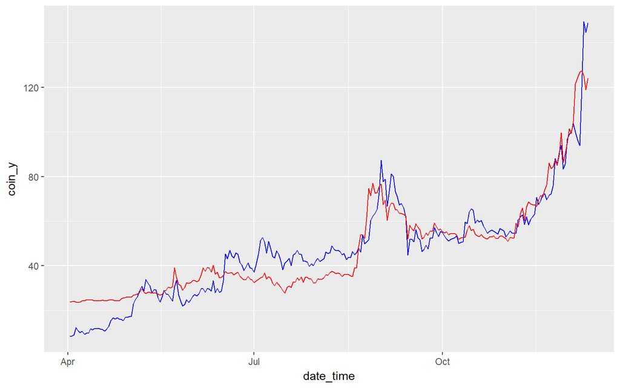

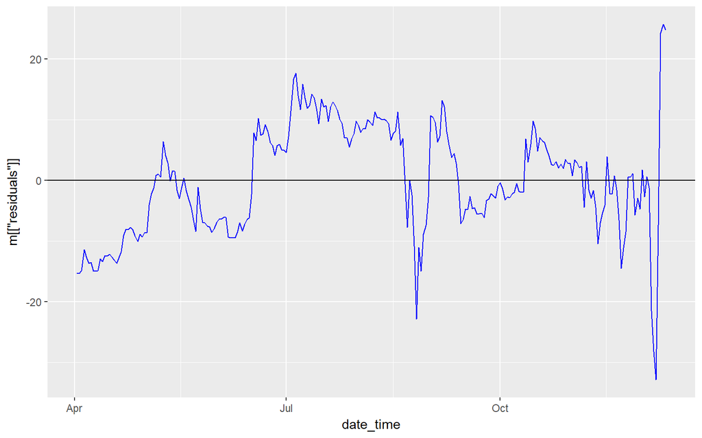

```
## [1] "Generating plots for USDT_XMR and USDT_LTC."
##
## Call:
## lm(formula = coin_y ~ coin_x, data = pricing_data_a)
##
## Residuals:
##     Min      1Q  Median      3Q     Max
## -39.621 -16.248   1.398  12.347  91.690
##
## Coefficients:
##             Estimate Std. Error t value             Pr(>|t|)
## (Intercept) -20.0584     2.7197  -7.375     0.00000000000234 ***
## coin_x        2.0037     0.0508  39.444 < 0.0000000000000002 ***
## ---
## Signif. codes:  0 '***' 0.001 '**' 0.01 '*' 0.05 '.' 0.1 ' ' 1
##
## Residual standard error: 19.8 on 253 degrees of freedom
## Multiple R-squared:  0.8601, Adjusted R-squared:  0.8596
## F-statistic:  1556 on 1 and 253 DF,  p-value: < 0.00000000000000022
```

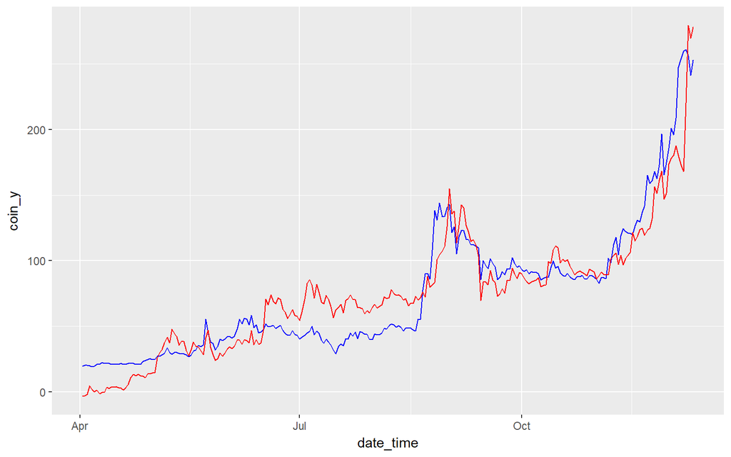

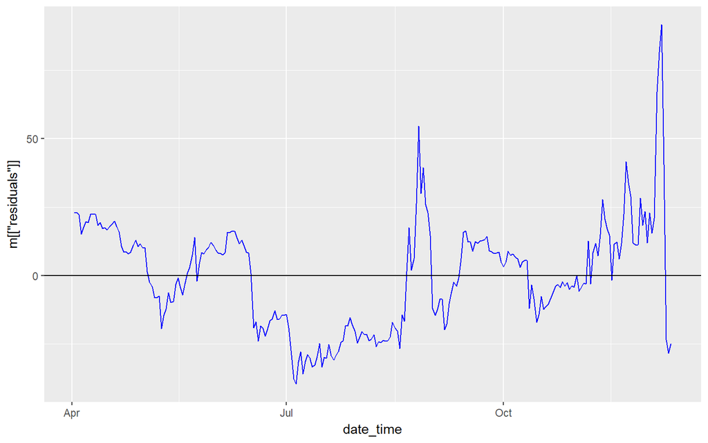

```
## [1] "Generating plots for USDT_LTC and USDT_BTC."
##
## Call:
## lm(formula = coin_y ~ coin_x, data = pricing_data_a)
##
## Residuals:
##     Min      1Q  Median      3Q     Max
## -47.055  -6.812  -0.207   6.198  33.944
##
## Coefficients:
##               Estimate Std. Error t value            Pr(>|t|)
## (Intercept) 16.6121845  1.1272904   14.74 <0.0000000000000002 ***
## coin_x       0.0075070  0.0002222   33.79 <0.0000000000000002 ***
## ---
## Signif. codes:  0 '***' 0.001 '**' 0.01 '*' 0.05 '.' 0.1 ' ' 1
##
## Residual standard error: 10.43 on 253 degrees of freedom
## Multiple R-squared:  0.8186, Adjusted R-squared:  0.8179
## F-statistic:  1142 on 1 and 253 DF,  p-value: < 0.00000000000000022
```

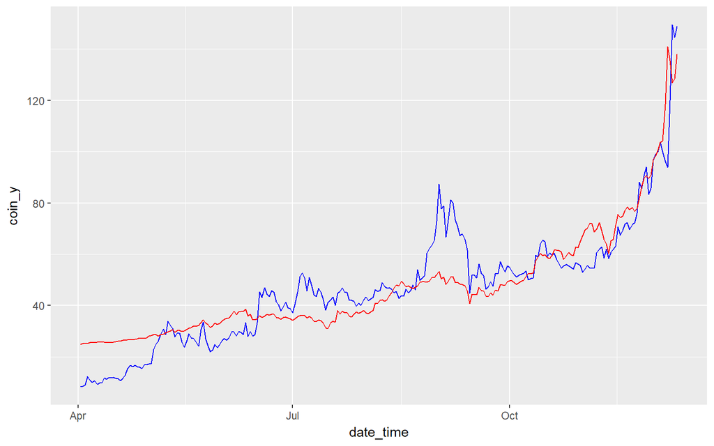

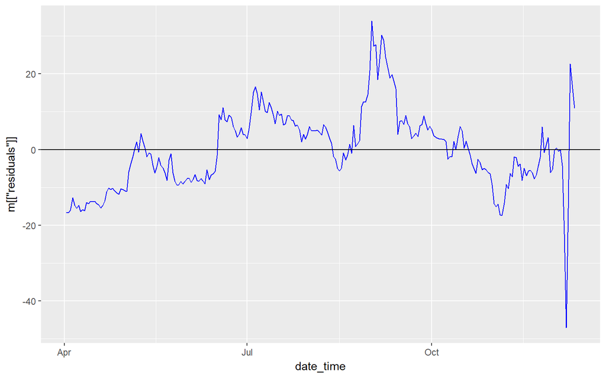

```
## [1] "Generating plots for USDT_DASH and USDT_XMR."
##
## Call:
## lm(formula = coin_y ~ coin_x, data = pricing_data_a)
##
## Residuals:
##      Min       1Q   Median       3Q      Max
## -143.738  -24.006   -6.528   23.647  208.969
##
## Coefficients:
##             Estimate Std. Error t value             Pr(>|t|)
## (Intercept) 29.44689    4.76139   6.185        0.00000000249 ***
## coin_x       2.97032    0.05174  57.409 < 0.0000000000000002 ***
## ---
## Signif. codes:  0 '***' 0.001 '**' 0.01 '*' 0.05 '.' 0.1 ' ' 1
##
## Residual standard error: 43.56 on 253 degrees of freedom
## Multiple R-squared:  0.9287, Adjusted R-squared:  0.9284
## F-statistic:  3296 on 1 and 253 DF,  p-value: < 0.00000000000000022
```

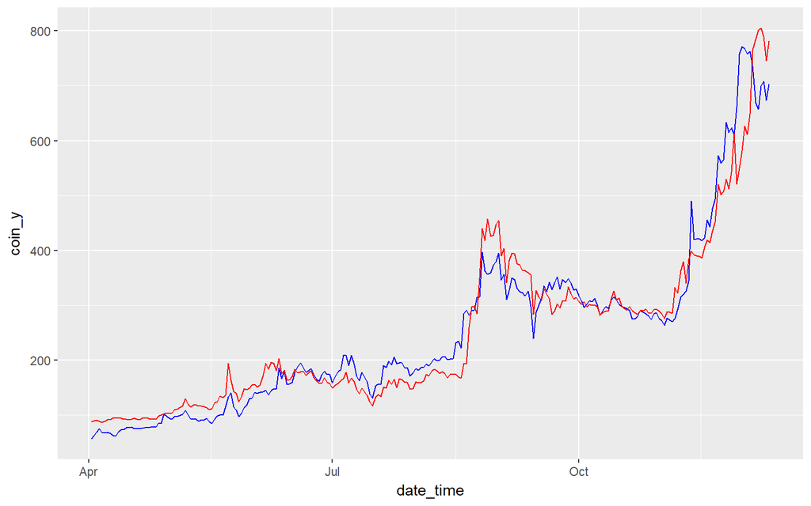

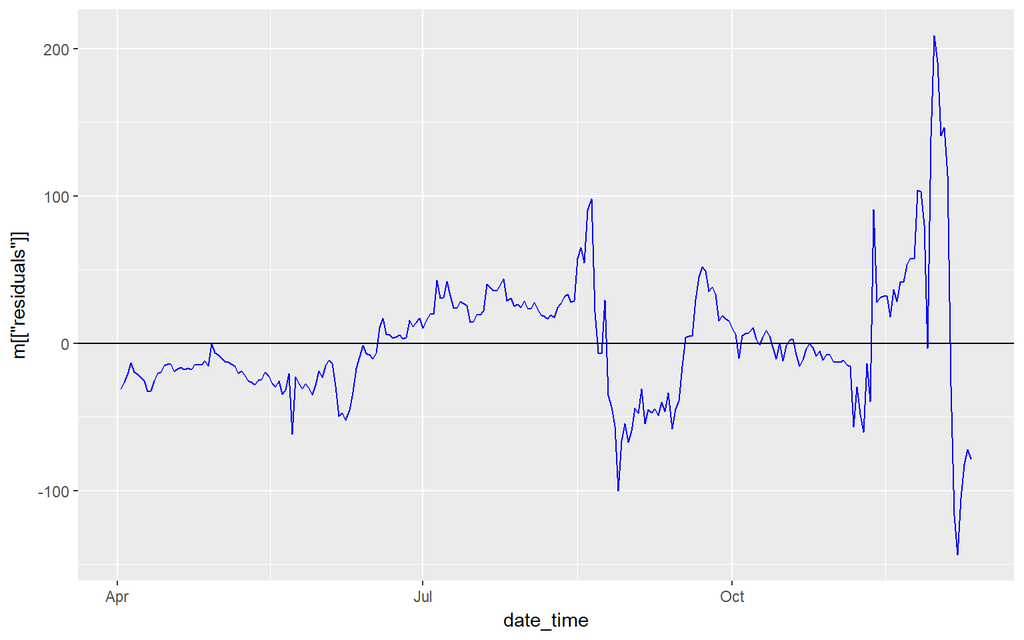

```
## [1] "Generating plots for BTC_FCT and BTC_ZEC."
##
## Call:
## lm(formula = coin_y ~ coin_x, data = pricing_data_a)
##
## Residuals:
##        Min         1Q     Median         3Q        Max
## -0.0033737 -0.0006233 -0.0001256  0.0007158  0.0038118
##
## Coefficients:
##               Estimate Std. Error t value            Pr(>|t|)
## (Intercept) 0.00009994 0.00015161   0.659                0.51
## coin_x      0.08181915 0.00213161  38.384 <0.0000000000000002 ***
## ---
## Signif. codes:  0 '***' 0.001 '**' 0.01 '*' 0.05 '.' 0.1 ' ' 1
##
## Residual standard error: 0.001014 on 253 degrees of freedom
## Multiple R-squared:  0.8534, Adjusted R-squared:  0.8529
## F-statistic:  1473 on 1 and 253 DF,  p-value: < 0.00000000000000022
```

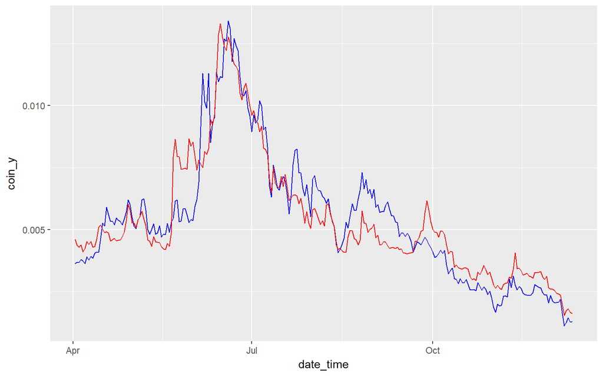

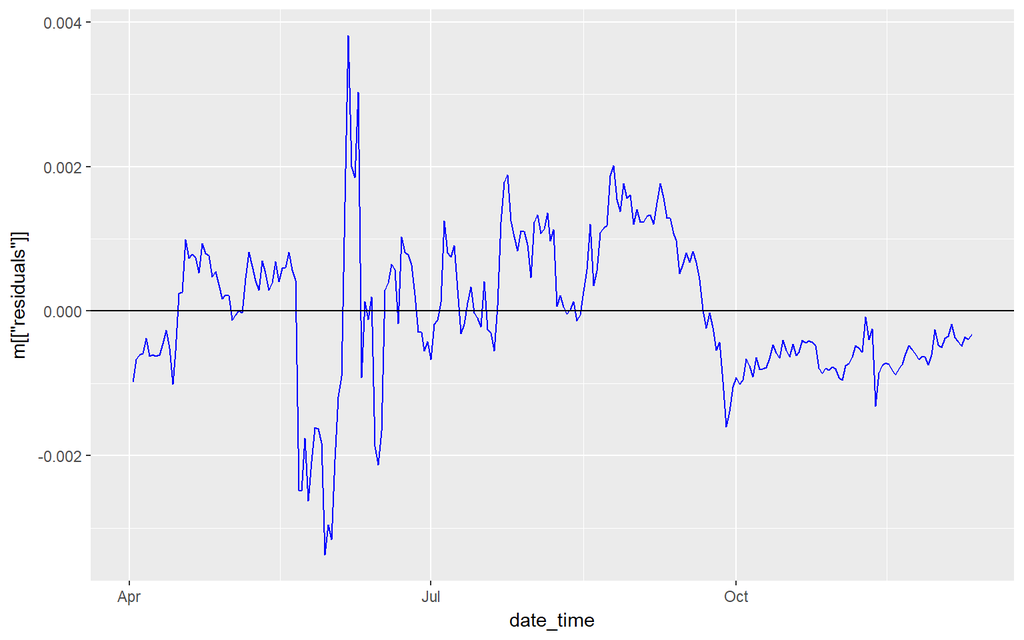

```
## [1] "Generating plots for BTC_DCR and BTC_REP."
##
## Call:
## lm(formula = coin_y ~ coin_x, data = pricing_data_a)
##
## Residuals:
##        Min         1Q     Median         3Q        Max
## -0.0041192 -0.0008143 -0.0002072  0.0009312  0.0044257
##
## Coefficients:
##              Estimate Std. Error t value            Pr(>|t|)
## (Intercept) 0.0026889  0.0002046   13.14 <0.0000000000000002 ***
## coin_x      0.8853925  0.0272224   32.52 <0.0000000000000002 ***
## ---
## Signif. codes:  0 '***' 0.001 '**' 0.01 '*' 0.05 '.' 0.1 ' ' 1
##
## Residual standard error: 0.001404 on 253 degrees of freedom
## Multiple R-squared:  0.807,  Adjusted R-squared:  0.8062
## F-statistic:  1058 on 1 and 253 DF,  p-value: < 0.00000000000000022
```

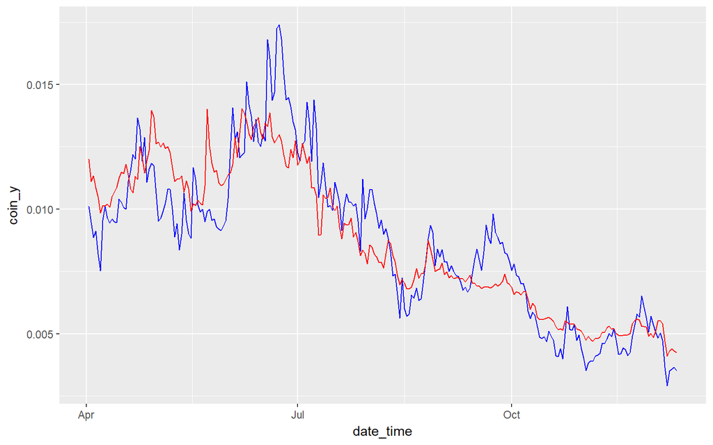

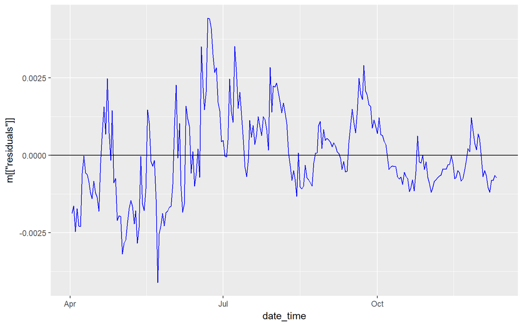

```
## [1] "Generating plots for BTC_ZEC and BTC_FCT."
##
## Call:
## lm(formula = coin_y ~ coin_x, data = pricing_data_a)
##
## Residuals:
##       Min        1Q    Median        3Q       Max
## -0.035992 -0.008100  0.000378  0.004874  0.041056
##
## Coefficients:
##              Estimate Std. Error t value             Pr(>|t|)
## (Intercept)  0.008423   0.001629   5.169          0.000000477 ***
## coin_x      10.430870   0.271752  38.384 < 0.0000000000000002 ***
## ---
## Signif. codes:  0 '***' 0.001 '**' 0.01 '*' 0.05 '.' 0.1 ' ' 1
##
## Residual standard error: 0.01145 on 253 degrees of freedom
## Multiple R-squared:  0.8534, Adjusted R-squared:  0.8529
## F-statistic:  1473 on 1 and 253 DF,  p-value: < 0.00000000000000022
```

[68 more figures not shown]

```r
for (i in 1:40) {
  coin_y <- coin_pairs[["coin_y"]][i]
  coin_x <- coin_pairs[["coin_x"]][i]
  print(str_c("Generating plots for ", coin_y, " and ", coin_x, "."))
  plot_coins(coin_y = pricing_data_a[[coin_y]], coin_x = pricing_data_a[[coin_x]])
}
```